# Library Beta Barcode Association Report

## 2.2 Summary Statistics

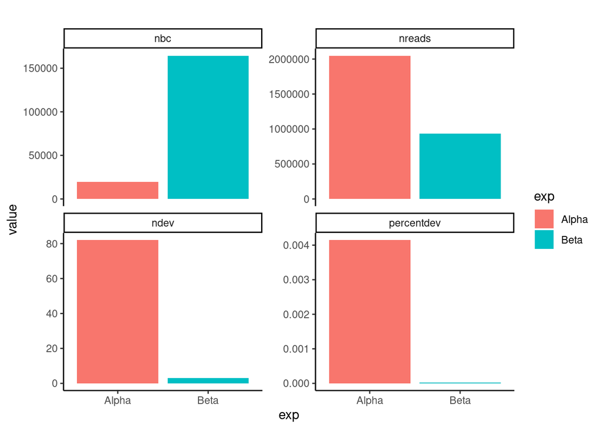

```r
summary <- all_filt %>%
  group_by(exp) %>%
  summarise(
    nbc = n(),
    nreads = sum(READS),
    ndev = sum(DEVIANTREADS > READS)
  )

summary$percentdev <- summary$ndev / summary$nbc
summary <- melt(summary, id.vars = "exp")

stats <- ggplot(summary, aes(x = exp, y = value, fill = exp)) +
  geom_col() +
  facet_wrap(~ variable, scales="free_y") +
  theme(axis.text.x = element_text(angle=45, hjust=1)) +
  theme_classic() +
  ggtitle("")

stats
```

```r
all_filt <- subset(all_filt, DEVIANTREADS / (READS + DEVIANTREADS) < 0.2)
```

# 3 Barcode representation

Most importantly, we want to make sure that the GREs are represented evenly in the library. This means, that if the CRS are equally present in the library, we would expect equal number of reads for each CRS after sequencing. To look into this, we first compute the number of reads per CRS. Then we rank each CRS, according to its number of reads (Rank 1: The CRS with the lowest number of reads).

## 3.1 How many reads represent one GRE?

Each dot represents a GRE ranked according to the number of reads by which it is represented.

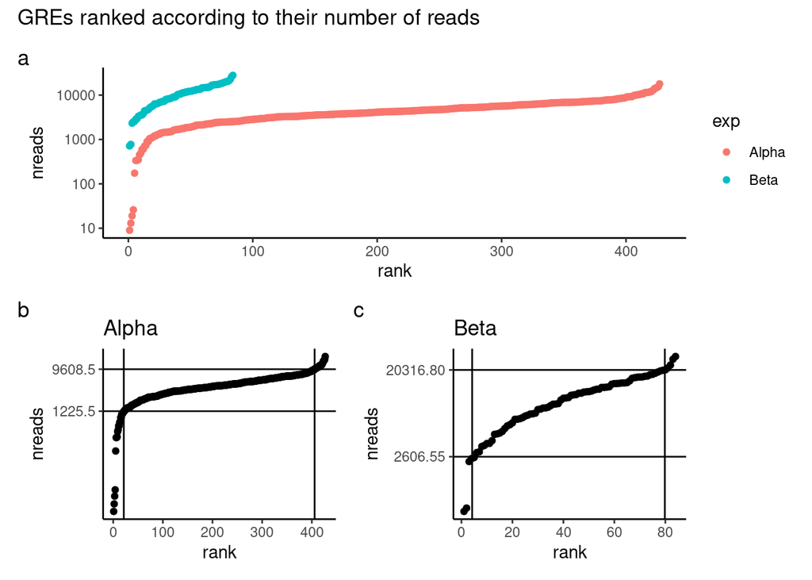

```r
read_per_crs <- all_filt %>%
  group_by(CRS, exp) %>%
  summarise(
    nreads = sum(READS),
    nbc = sum(READS >= if_else(unique(exp) == "Recloned", 10, 3)))

read_per_crs <- split(read_per_crs, read_per_crs$exp)
read_per_crs <- lapply(read_per_crs, function(x) {x$rank <- rank(x$nreads); return(x)})
q <- lapply(read_per_crs, function(x) data.frame(q = quantile(x$nreads, c(0.05,0.95)), exp = unique(x$exp)))
q <- do.call(rbind, q)
read_per_crs <- do.call(rbind, read_per_crs)

#png("001_comparisonA.png",width=1024,height=768,res=150)
#qplot(x = rank , y = nreads, data= read_per_crs, color =exp)  + scale_y_log10()

all_in_one <- ggplot(read_per_crs, aes(x = rank, y = nreads, color = exp)) +
  scale_y_log10() +
  geom_point() +
  theme_classic()

plots <- lapply(split(read_per_crs, read_per_crs$exp), function(x)
  qplot(x = rank , y = nreads, data= x)  + scale_y_log10() + ggtitle(unique(x$exp)) + theme_classic() +
    geom_vline(xintercept = c(0.05,0.95)*nrow(x))+
    geom_hline(yintercept = subset(q, exp == unique(x$exp))$q) +
    scale_y_log10(breaks = subset(q, exp == unique(x$exp))$q))

all_in_one /  wrap_plots(plots) +
  plot_annotation(title = 'GREs ranked according to their number of reads',
                  tag_levels = 'a')
```

```r
quantiles_libraries <- read_per_crs %>%
  group_by(exp) %>%
  summarise(quantile = scales::percent(c(0.05, 0.5, 0.95)),
            nreads = quantile(nreads, c(0.05, 0.5, 0.95)),
            mean = mean(nreads))

#now we compute the foldchanges between the reads of the 5% and the 95% quantile.

quantiles_libraries_read_fc <- quantiles_libraries %>%
  group_by(exp) %>%
  mutate(fc = (nreads[3] / nreads[1]))
```

This plot represented in numbers. Additionally, we calculate the mean number of reads per GRE.

```r
quantiles_libraries_read_fc %>%
  group_by(exp) %>%
  summarise(fc = mean(fc), mean = mean(mean))
```

```
## # A tibble: 2 × 3
##   exp      fc   mean
##   <chr> <dbl>  <dbl>
## 1 Alpha  7.84  5029
## 2 Beta   7.79 11258.
```

## 3.2 How many barcodes represent one GRE?

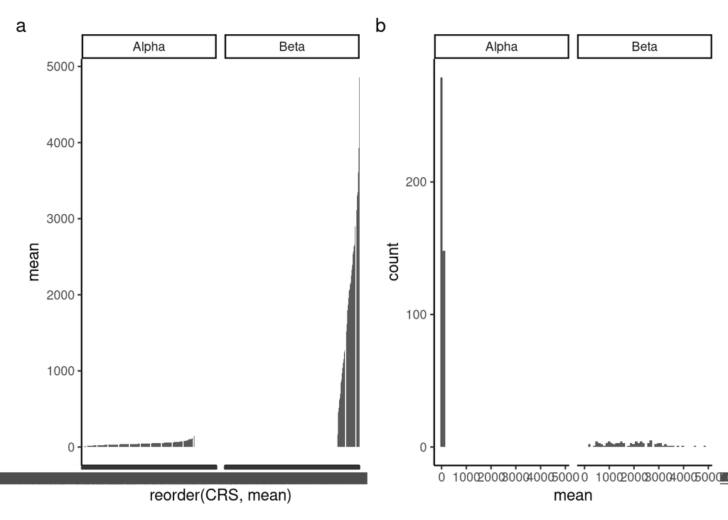

```r
#hier nochmal schauen ob des Sinn macht, ich glaub ich berechne hier vllt was anderes als ich will
bc_per_GRE <- read_per_crs %>%
  group_by(exp, CRS) %>%
  summarise(mean = mean(nbc)) %>% # hier stimmt was nicht glaube
  arrange(desc(mean))

mean_bcs_per_GRE <- ggplot(data=bc_per_GRE, aes(x=reorder(CRS, mean), y=mean)) +
  geom_bar(stat="identity") +
  facet_wrap(~ exp) +
  theme_classic()

bc_per_GRE_hist_per_lib <- ggplot(data = bc_per_GRE, aes(x = mean)) +
  geom_histogram(bins = 50) +
  facet_wrap(~ exp) +
  theme_classic()

mean_bcs_per_GRE + bc_per_GRE_hist_per_lib +
  plot_annotation(tag_levels = 'a')
```

# 4 GFP and Guide Barcodes

Last, we are checking if the GFP and the GUIDE Barcodes behave differently. Before, we treated these two barcodes as if it was one (merged string). For this, we split the barcode into the 15 first letters (GFP BC) and the 15 last letters (guide BC).

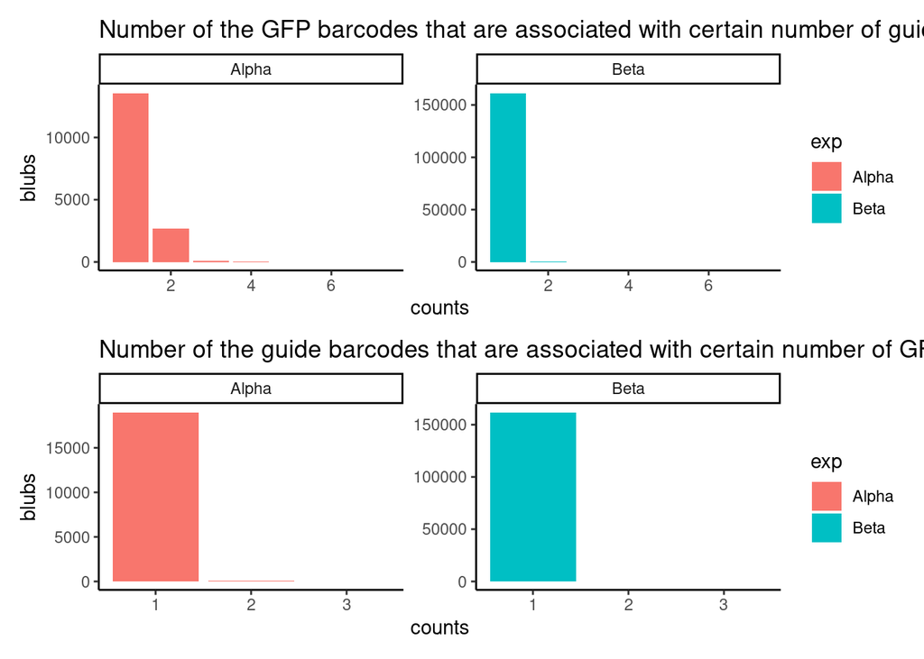

```r
all_filt$GFP_BC <- substr(all_filt$BARCODE, 1,15)
all_filt$gRNA <- substr(all_filt$BARCODE, 16,30)

mostAbundant <- function(vector) {
  a <- table(vector)
  names(a)[which.max(a)]
}

#From what i understand, is that the GFP barcode is more complex than the guide barcode

gRNA_summary <- all_filt %>%
  group_by(gRNA, exp) %>%
  summarise(
    nCRS = n_distinct(CRS),
    mainCRS = mostAbundant(CRS), #selects the most abundant one (the one represented by the highest no of barcodes) because in rare cases the one guide barcode is associated with more than one CRS
    n_gfp_bcs.mainCRS = n_distinct(GFP_BC[CRS == mainCRS]),
    n_gfp_bcs.otherCRS = n_distinct(GFP_BC[CRS != mainCRS]))

GFP_summary <- all_filt %>%
  group_by(GFP_BC, exp) %>%
  summarise(
    nCRS = n_distinct(CRS),
    mainCRS = mostAbundant(CRS),
    nguide.mainCRS = n_distinct(gRNA[CRS == mainCRS]),
    nguide.otherCRS = n_distinct(gRNA[CRS != mainCRS]))

to_plot_GFP <- GFP_summary %>%
  group_by(exp) %>%
  summarise(
    blubs = table(nguide.mainCRS))

#for different libs this needs to be adjusted
to_plot_GFP$counts <- c(1:nrow(to_plot_GFP %>% filter(exp == "Alpha")), 1:nrow(to_plot_GFP %>% filter(exp == "Beta")))

to_plot_guide <- gRNA_summary %>%
  group_by(exp) %>%
  summarise(
    blubs = table(n_gfp_bcs.mainCRS))

to_plot_guide$counts <- c(1:nrow(to_plot_guide %>% filter(exp == "Alpha")), 1:nrow(to_plot_guide %>% filter(exp == "Beta")))


guide_barcodes <- ggplot(to_plot_guide, aes(x = counts, y = blubs, fill = exp)) +
  geom_col() +
  facet_wrap(~ exp, scales="free_y") +
  theme(axis.text.x = element_text(angle=45, hjust=1)) +
  theme_classic() +
  ggtitle("Number of the GFP barcodes that are associated with certain number of guide barcodes")

gfp_barcodes <- ggplot(to_plot_GFP, aes(x = counts, y = blubs, fill = exp)) +
  geom_col() +
  facet_wrap(~ exp, scales="free_y") +
  theme(axis.text.x = element_text(angle=45, hjust=1)) +
  theme_classic() +
  ggtitle("Number of the guide barcodes that are associated with certain number of GFP barcodes")

guide_barcodes / gfp_barcodes
```